# Japenese Restaurant Visitor Exploratory

R & Python

Karim Mezhoud & Martin Henze

2023-10-23

# 1 Introduction

This is an extensive Exploratory Data Analysis for the [Recruit Restaurant Visitor Forecasting](https://www.kaggle.com/c/recruit-restaurant-visitor-forecasting) competition with the powers of [tidy R](http://tidyverse.org/) and [ggplot2](http://ggplot2.tidyverse.org/). Also We tried to translate the main R code to Python.

The aim of this challenge is to predict the future numbers of restaurant visitors. This makes it a Time Series Forecasting problem. The data was collected from Japanese restaurants. As we will see, the data set is small and easily accessible without requiring much memory or computing power. Therefore, this competition is particularly suited for beginners.

The data comes in the shape of 8 relational files which are derived from two separate Japanese websites that collect user information: “Hot Pepper Gourmet (hpg): similar to Yelp” (search and reserve) and “AirREGI / Restaurant Board (air): similar to Square” (reservation control and cash register). The training data is based on the time range of Jan 2016 - most of Apr 2017, while the test set includes the last week of Apr plus May 2017. The test data “intentionally spans a holiday week in Japan called the ‘Golden Week.’ The [data description](https://www.kaggle.com/c/recruit-restaurant-visitor-forecasting/data) further notes that:”There are days in the test set where the restaurant were closed and had no visitors. These are ignored in scoring. The training set omits days where the restaurants were closed.”

Those are the individual files:

- **air_visit_data.csv**: historical visit data for the *air* restaurants. This is essentially the main training data set.
- **air_reserve.csv** / **hpg_reserve.csv**: reservations made through the *air* / *hpg* systems.
- **air_store_info.csv** / **hpg_store_info.csv**: details about the *air* / *hpg* restaurants including genre and location.
- **store_id_relation.csv**: connects the *air* and *hpg* ids
- **date_info.csv**: essentially flags the Japanese holidays.
- **sample_submission.csv**: serves as the *test* set. The *id* is formed by combining the *air* id with the visit date.

*Thank you all for the upvotes, critical feedback, and continued support!*

# 2 Preparations

## 2.1 Set Python and R Envirments and load packages

### 2.1.1 for R to use python3

```r
# Set python environment and version in RStudio ;-)
reticulate::use_python("/usr/bin/python3.10", required = TRUE)
reticulate::py_config()
```

```
## python:         /usr/bin/python3.10
## libpython:      /usr/lib/python3.10/config-3.10-x86_64-linux-gnu/libpython3.10.so
## pythonhome:     //usr://usr
## version:        3.10.12 (main, Jun 11 2023, 05:26:28) [GCC 11.4.0]
## numpy:          /home/kirus/.local/lib/python3.10/site-packages/numpy
## numpy_version:  1.26.0
##
## NOTE: Python version was forced by use_python() function
```

```r
# check module availability
#reticulate::py_module_available("numpy")
#reticulate::py_module_available("matplotlib")
#reticulate::py_module_available("seaborn")
```

### 2.1.2 Set Language

```r
#Sys.setlocale("LC_ALL","English")
Sys.setenv(LANG = "en_US.UTF-8")
Sys.setenv("LANGUAGE"="En")
```

```python
import locale
locale.setlocale(locale.LC_ALL,'en_US.utf8')
```

```
## 'en_US.utf8'
```

### 2.1.3 Check R libraries paths

```r
.libPaths()
```

```
## [1] "/home/kirus/R/x86_64-pc-linux-gnu-library/4.3"
## [2] "/usr/local/lib/R/site-library"
## [3] "/usr/lib/R/site-library"
## [4] "/usr/lib/R/library"
```

### 2.1.4 Check the path of R envirment used by python

```python
import os
print(os.environ['R_HOME'])
```

```
## /usr/lib/R
```

```python
# os.environ['R_HOME'] = "/home/kirus/R/x86_64-pc-linux-gnu-library/4.3"
# print(os.environ['R_HOME'])
```

- We need to set R libraries path when called by Python.
- Two paths will be used:
  - `/usr/lib/R/library` for packages installed with root profile during installing R base,
  - `/home/kirus/R/x86_64-pc-linux-gnu-library/4.3` for packages installed by user without root profile.

### 2.1.5 Check which R version and libraries paths used by `rpy2``

```python
import rpy2.rinterface
#rpy2.rinterface.set_initoptions((b'rpy2', b'--no-save', b'--no-restore', b'--quiet'))
from rpy2.robjects.packages import importr
base = importr('base', lib_loc= '/usr/lib/R/library/')
print(base.version)
```

[output not shown]

```python
print(base._libPaths())
```

## 2.2 Load libraries

We load a range of libraries for general data wrangling and general visualisation together with more specialised tools.

```r
# general visualisation
library('ggplot2') # visualisation
library('scales') # visualisation
library('grid') # visualisation
library('gridExtra') # visualisation
library('RColorBrewer') # visualisation
library('corrplot') # visualisation

# general data manipulation
library('dplyr') # data manipulation
library('readr') # input/output
library('data.table') # data manipulation
library('DT') # display table
library('tibble') # data wrangling
library('tidyr') # data wrangling
library('stringr') # string manipulation
library('forcats') # factor manipulation

# specific visualisation
library('ggrepel') # visualisation
library('ggridges') # visualisation
library('ggExtra') # visualisation
library('ggforce') # visualisation
library('viridis') # visualisation

# specific data manipulation
library('lazyeval') # data wrangling
library('broom') # data wrangling
library('purrr') # string manipulation

# Date plus forecast
library('lubridate') # date and time
library('timeDate') # date and time
library('tseries') # time series analysis
library('forecast') # time series analysis
#library('prophet') # time series analysis
library('timetk') # time series analysis

# Maps / geospatial
library('geosphere') # geospatial locations
library('leaflet') # maps
library('leaflet.extras') # maps
library('maps') # maps

library(reticulate) # interface to python
```

```python
#pip3 install matplotlib
#pip3 install seaborn
#pip3 install scikit-learn
#pip3 install rpy2
# pip install git+https://github.com/h2oai/datatable
# pip install ipywidgets==7.0.1

from rpy2 import robjects
from rpy2.robjects.packages import importr, data
import rpy2.robjects.packages as rpackages
import rpy2.robjects as ro
from rpy2.robjects import pandas2ri
import matplotlib
import matplotlib.pyplot as plt
import pandas as pd
import numpy as np
import seaborn as sns
import locale
from statsmodels.nonparametric.smoothers_lowess import lowess
from matplotlib.gridspec import GridSpec
import matplotlib.dates as mdates
from matplotlib.ticker import FormatStrFormatter
import folium
from folium.plugins import MarkerCluster

#from IPython.display import display, HTML # displays html tobale in Rmarkdown
#import ipywidgets
#import qgrid  # display dataframe like DT::datatable in Rmarkdown document
#import datatable as dt
#from sklearn.model_selection import train_test_split
from collections import Counter
from datetime import datetime
```

## 2.3 plot iris datasets

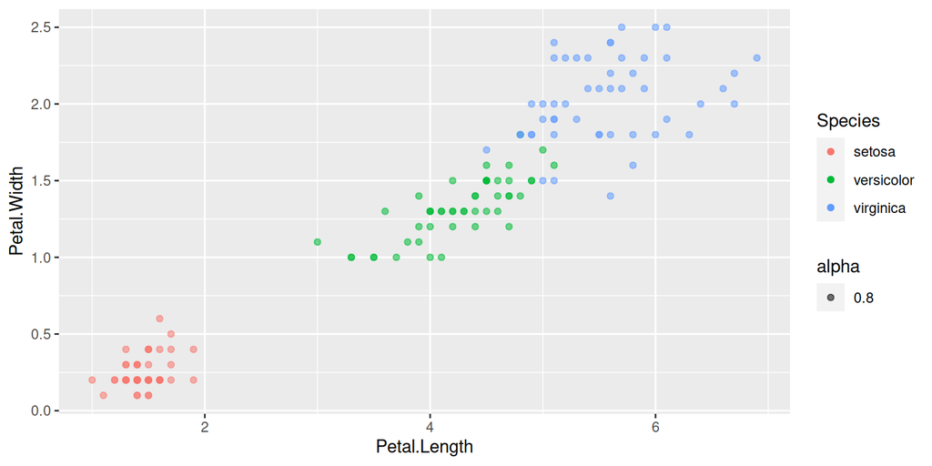

```r
iris %>%
ggplot()+
aes(x=Petal.Length,y=Petal.Width,color=Species, alpha=0.8) +
 geom_point()
```

```r
#datasets::iris
```

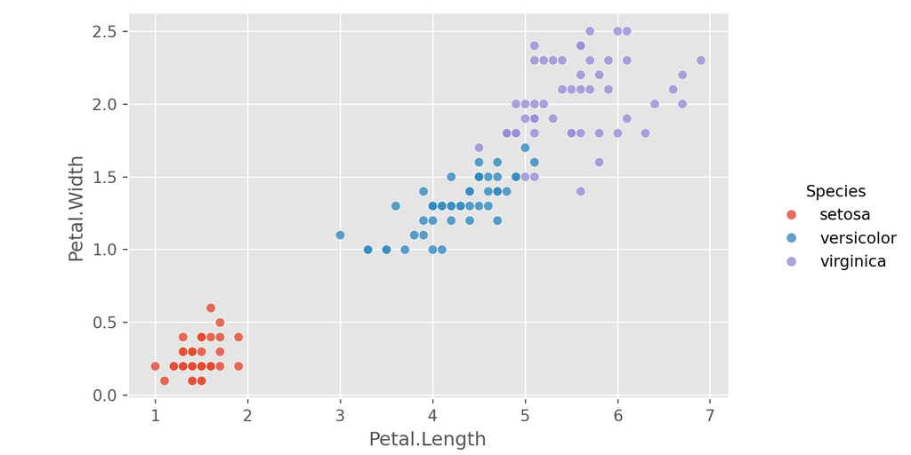

```python
## Load iris from python
#iris = sns.load_dataset('iris')

# load iris from R
datasets = rpackages.importr('datasets',
            lib_loc= '/usr/lib/R/library/')
iris = data(datasets).fetch('iris')['iris']

# convert R dataframe to pandas df
# (https://rpy2.github.io/doc/latest/html/generated_rst/pandas.html)
with (ro.default_converter + pandas2ri.converter).context():
  iris = ro.conversion.get_conversion().rpy2py(iris)


#sns.set_style("darkgrid")
plt.style.use('ggplot')
#fi = sns.FacetGrid(iris, hue ="Species",
#              height = 6).map(plt.scatter,
#                              'Petal.Length',
#                              'Petal.Width').add_legend()

fi=sns.relplot(x="Petal.Length",
               y="Petal.Width",
               data=iris, alpha=0.8,
               hue='Species')
fi.fig.set_figheight(4)
fi.fig.set_figwidth(8)
plt.show()
```

## 2.4 Helper functions

```r
# Define multiple plot function
#
# ggplot objects can be passed in ..., or to plotlist (as a list of ggplot objects)
# - cols:   Number of columns in layout
# - layout: A matrix specifying the layout. If present, 'cols' is ignored.
#
# If the layout is something like matrix(c(1,2,3,3), nrow=2, byrow=TRUE),
# then plot 1 will go in the upper left, 2 will go in the upper right, and
# 3 will go all the way across the bottom.
#
multiplot <- function(..., plotlist=NULL, file, cols=1, layout=NULL) {

  # Make a list from the ... arguments and plotlist
  plots <- c(list(...), plotlist)

  numPlots = length(plots)

  # If layout is NULL, then use 'cols' to determine layout
  if (is.null(layout)) {
    # Make the panel
    # ncol: Number of columns of plots
    # nrow: Number of rows needed, calculated from # of cols
    layout <- matrix(seq(1, cols * ceiling(numPlots/cols)),
                    ncol = cols, nrow = ceiling(numPlots/cols))
  }

 if (numPlots==1) {
    print(plots[[1]])

  } else {
    # Set up the page
    grid.newpage()
    pushViewport(viewport(layout = grid.layout(nrow(layout), ncol(layout))))

    # Make each plot, in the correct location
    for (i in 1:numPlots) {
      # Get the i,j matrix positions of the regions that contain this subplot
      matchidx <- as.data.frame(which(layout == i, arr.ind = TRUE))

      print(plots[[i]], vp = viewport(layout.pos.row = matchidx$row,
                                      layout.pos.col = matchidx$col))
    }
  }
}
```

We use matplotlib to create subplots. The function multiplot now works with `*args` to accept an arbitrary number of plots, and the cols argument determines the number of columns in the layout. If layout is not provided, it is calculated from cols and the number of plots.

The example at the end demonstrates how to use the multiplot function with two plots (y1 and y2) arranged in two columns.

```python
import matplotlib.pyplot as plt
from matplotlib.gridspec import GridSpec

def multiplot(*args, plotlist=None, file=None, cols=1, layout=None):
    plots = list(args) + (plotlist if plotlist else [])
    num_plots = len(plots)

    if layout is None:
        rows = (num_plots - 1) // cols + 1
        layout = [(i // cols, i % cols) for i in range(num_plots)]

    if num_plots == 1:
        plt.subplot2grid((rows, cols), (0, 0))
        plt.plot(plots[0])

    else:
        fig = plt.figure()
        gs = GridSpec(rows, cols)

        for i, plot in enumerate(plots):
            ax = fig.add_subplot(gs[layout[i]])
            ax.plot(plot)

    if file:
        plt.savefig(file)
    else:
        plt.show()

# Example usage
#import numpy as np

#x = np.linspace(0, 10, 100)
#y1 = np.sin(x)
#y2 = np.cos(x)

#multiplot(y1, y2, cols=2)
```

An other version using `add_gridspec` to create a layout for multiple plots:

```python
def multiplot(*args, plotlist=None, file=None, cols=1, layout=None):
    plots = list(args) + (plotlist if plotlist else [])
    num_plots = len(plots)

    if layout is None:
        rows = (num_plots - 1) // cols + 1

    fig = plt.figure()

    if num_plots == 1:
        plt.subplot2grid((rows, cols), (0, 0), colspan=cols)
        plt.plot(plots[0])

    else:
        gs = GridSpec(rows, cols)

        for i, plot in enumerate(plots):
            ax = fig.add_subplot(gs[i // cols, i % cols])
            ax.plot(plot)

    if file:
        plt.savefig(file)
    else:
        plt.show()
```

## 2.5 Load Data

```r
air_visits <- data.table::fread(str_c("data/air_visit_data.csv"))
air_reserve <- data.table::fread(str_c('data/air_reserve.csv'))
air_store <- data.table::fread(str_c('data/air_store_info.csv'))
holidays <- data.table::fread(str_c('data/date_info.csv'))
hpg_reserve <- data.table::fread(str_c('data/hpg_reserve.csv'))
hpg_store <- data.table::fread(str_c('data/hpg_store_info.csv'))
store_ids <- data.table::fread(str_c('data/store_id_relation.csv'))
test <- data.table::fread(str_c('data/sample_submission.csv'))
```

In this Python code, we use the pandas library to read the CSV files. Each read_csv function call reads a CSV file into a DataFrame. The variable names (air_visit, air_reserve, etc.) will be DataFrames that you can use for data manipulation and analysis.

```python
air_visits = pd.read_csv("data/air_visit_data.csv")
air_reserve = pd.read_csv("data/air_reserve.csv")
air_store = pd.read_csv("data/air_store_info.csv")
holidays = pd.read_csv("data/date_info.csv")
hpg_reserve = pd.read_csv("data/hpg_reserve.csv")
hpg_store = pd.read_csv("data/hpg_store_info.csv")
store_ids = pd.read_csv("data/store_id_relation.csv")
test = pd.read_csv("data/sample_submission.csv")
```

# 3 Overview: File structure and content

As a first step let’s have an overview of the data sets.

## 3.1 Air visits

```r
air_visits %>%
  head(10) %>%
  DT::datatable()
```

|  | air_store_id | visit_date | visitors |
| --- | --- | --- | --- |
| 1 | air_ba937bf13d40fb24 | 2016-01-13 | 25 |
| 2 | air_ba937bf13d40fb24 | 2016-01-14 | 32 |
| 3 | air_ba937bf13d40fb24 | 2016-01-15 | 29 |
| 4 | air_ba937bf13d40fb24 | 2016-01-16 | 22 |
| 5 | air_ba937bf13d40fb24 | 2016-01-18 | 6 |
| 6 | air_ba937bf13d40fb24 | 2016-01-19 | 9 |
| 7 | air_ba937bf13d40fb24 | 2016-01-20 | 31 |
| 8 | air_ba937bf13d40fb24 | 2016-01-21 | 21 |
| 9 | air_ba937bf13d40fb24 | 2016-01-22 | 18 |
| 10 | air_ba937bf13d40fb24 | 2016-01-23 | 26 |

We find that this file contains the *visitors* numbers for each *visit_date* and *air_store_id*. The date feature should be transformed into a time-series format. There are 829 different stores, which is a small data set:

```r
air_visits %>%
  distinct(air_store_id) %>%
  nrow()
```

```
## [1] 829
```

qgrid and ipywidgets verions are not compatible and have a issue to render html table like `DT::datatable()`.

```python
#air_visits = pd.DataFrame(air_visits)

# Show the DataFrame using qgrid in Python
#qgrid_widget = qgrid.show_grid(air_visits, show_toolbar=True)
#qgrid_widget.head(10)

#html = air_visits.head(10).to_html()
#display(HTML(html))
#print(html)
air_visits.head(10)
```

```
##            air_store_id  visit_date  visitors
## 0  air_ba937bf13d40fb24  2016-01-13        25
## 1  air_ba937bf13d40fb24  2016-01-14        32
## 2  air_ba937bf13d40fb24  2016-01-15        29
## 3  air_ba937bf13d40fb24  2016-01-16        22
## 4  air_ba937bf13d40fb24  2016-01-18         6
## 5  air_ba937bf13d40fb24  2016-01-19         9
## 6  air_ba937bf13d40fb24  2016-01-20        31
## 7  air_ba937bf13d40fb24  2016-01-21        21
## 8  air_ba937bf13d40fb24  2016-01-22        18
## 9  air_ba937bf13d40fb24  2016-01-23        26
```

```python
air_visits['air_store_id'].nunique()
```

```
## 829
```

## 3.2 Air Reserve

```r
air_reserve %>%
  head(10) %>%
  DT::datatable()
```

|  | air_store_id | visit_datetime | reserve_datetime | reserve_visitors |
| --- | --- | --- | --- | --- |
| 1 | air_877f79706adbfb06 | 2016-01-01T19:00:00Z | 2016-01-01T16:00:00Z | 1 |
| 2 | air_db4b38ebe7a7ceff | 2016-01-01T19:00:00Z | 2016-01-01T19:00:00Z | 3 |
| 3 | air_db4b38ebe7a7ceff | 2016-01-01T19:00:00Z | 2016-01-01T19:00:00Z | 6 |
| 4 | air_877f79706adbfb06 | 2016-01-01T20:00:00Z | 2016-01-01T16:00:00Z | 2 |
| 5 | air_db80363d35f10926 | 2016-01-01T20:00:00Z | 2016-01-01T01:00:00Z | 5 |
| 6 | air_db80363d35f10926 | 2016-01-02T01:00:00Z | 2016-01-01T16:00:00Z | 2 |
| 7 | air_db80363d35f10926 | 2016-01-02T01:00:00Z | 2016-01-01T15:00:00Z | 4 |
| 8 | air_3bb99a1fe0583897 | 2016-01-02T16:00:00Z | 2016-01-02T14:00:00Z | 2 |
| 9 | air_3bb99a1fe0583897 | 2016-01-02T16:00:00Z | 2016-01-01T20:00:00Z | 2 |
| 10 | air_2b8b29ddfd35018e | 2016-01-02T17:00:00Z | 2016-01-02T17:00:00Z | 2 |

We find that the *air* reservations include the *date* and *time* of the reservation, as well as those of the visit. We have reservation numbers for 314 *air* stores:

```r
air_reserve %>% distinct(air_store_id) %>% nrow()
```

```
## [1] 314
```

```python
air_reserve.head(10)
```

```
##            air_store_id  ... reserve_visitors
## 0  air_877f79706adbfb06  ...                1
## 1  air_db4b38ebe7a7ceff  ...                3
## 2  air_db4b38ebe7a7ceff  ...                6
## 3  air_877f79706adbfb06  ...                2
## 4  air_db80363d35f10926  ...                5
## 5  air_db80363d35f10926  ...                2
## 6  air_db80363d35f10926  ...                4
## 7  air_3bb99a1fe0583897  ...                2
## 8  air_3bb99a1fe0583897  ...                2
## 9  air_2b8b29ddfd35018e  ...                2
##
## [10 rows x 4 columns]
```

```python
air_reserve['air_store_id'].nunique()
```

```
## 314
```

## 3.3 HPG Reserve

```r
  hpg_reserve %>%
  head(10) %>%
  DT::datatable()
```

|  | hpg_store_id | visit_datetime | reserve_datetime | reserve_visitors |
| --- | --- | --- | --- | --- |
| 1 | hpg_c63f6f42e088e50f | 2016-01-01T11:00:00Z | 2016-01-01T09:00:00Z | 1 |
| 2 | hpg_dac72789163a3f47 | 2016-01-01T13:00:00Z | 2016-01-01T06:00:00Z | 3 |
| 3 | hpg_c8e24dcf51ca1eb5 | 2016-01-01T16:00:00Z | 2016-01-01T14:00:00Z | 2 |
| 4 | hpg_24bb207e5fd49d4a | 2016-01-01T17:00:00Z | 2016-01-01T11:00:00Z | 5 |
| 5 | hpg_25291c542ebb3bc2 | 2016-01-01T17:00:00Z | 2016-01-01T03:00:00Z | 13 |
| 6 | hpg_28bdf7a336ec6a7b | 2016-01-01T17:00:00Z | 2016-01-01T15:00:00Z | 2 |
| 7 | hpg_2a01a042bca04ad9 | 2016-01-01T17:00:00Z | 2016-01-01T17:00:00Z | 2 |
| 8 | hpg_2a84dd9f4c140b82 | 2016-01-01T17:00:00Z | 2016-01-01T15:00:00Z | 2 |
| 9 | hpg_2ad179871696901f | 2016-01-01T17:00:00Z | 2016-01-01T13:00:00Z | 2 |
| 10 | hpg_2c1d989eedb0ff83 | 2016-01-01T17:00:00Z | 2016-01-01T15:00:00Z | 6 |

The *hpg* reservations file follows the same structure as the corresponding *air* file. We have reservation numbers for 13325 *hpg* stores:

```r
hpg_reserve %>% distinct(hpg_store_id) %>% nrow()
```

```
## [1] 13325
```

```python
hpg_reserve.head(10)
```

```
##            hpg_store_id  ... reserve_visitors
## 0  hpg_c63f6f42e088e50f  ...                1
## 1  hpg_dac72789163a3f47  ...                3
## 2  hpg_c8e24dcf51ca1eb5  ...                2
## 3  hpg_24bb207e5fd49d4a  ...                5
## 4  hpg_25291c542ebb3bc2  ...               13
## 5  hpg_28bdf7a336ec6a7b  ...                2
## 6  hpg_2a01a042bca04ad9  ...                2
## 7  hpg_2a84dd9f4c140b82  ...                2
## 8  hpg_2ad179871696901f  ...                2
## 9  hpg_2c1d989eedb0ff83  ...                6
##
## [10 rows x 4 columns]
```

```python
hpg_reserve['hpg_store_id'].nunique()
```

```
## 13325
```

## 3.4 Air Store

```r
air_store %>%
  head(10) %>%
  datatable()
```

|  | air_store_id | air_genre_name | air_area_name | latitude | longitude |
| --- | --- | --- | --- | --- | --- |
| 1 | air_0f0cdeee6c9bf3d7 | Italian/French | Hyōgo-ken Kōbe-shi Kumoidōri | 34.6951242 | 135.1978525 |
| 2 | air_7cc17a324ae5c7dc | Italian/French | Hyōgo-ken Kōbe-shi Kumoidōri | 34.6951242 | 135.1978525 |
| 3 | air_fee8dcf4d619598e | Italian/French | Hyōgo-ken Kōbe-shi Kumoidōri | 34.6951242 | 135.1978525 |
| 4 | air_a17f0778617c76e2 | Italian/French | Hyōgo-ken Kōbe-shi Kumoidōri | 34.6951242 | 135.1978525 |
| 5 | air_83db5aff8f50478e | Italian/French | Tōkyō-to Minato-ku Shibakōen | 35.6580681 | 139.7515992 |
| 6 | air_99c3eae84130c1cb | Italian/French | Tōkyō-to Minato-ku Shibakōen | 35.6580681 | 139.7515992 |
| 7 | air_f183a514cb8ff4fa | Italian/French | Tōkyō-to Minato-ku Shibakōen | 35.6580681 | 139.7515992 |
| 8 | air_6b9fa44a9cf504a1 | Italian/French | Tōkyō-to Minato-ku Shibakōen | 35.6580681 | 139.7515992 |
| 9 | air_0919d54f0c9a24b8 | Italian/French | Tōkyō-to Minato-ku Shibakōen | 35.6580681 | 139.7515992 |
| 10 | air_2c6c79d597e48096 | Italian/French | Tōkyō-to Minato-ku Shibakōen | 35.6580681 | 139.7515992 |

We find that the *air_store* info includes the name of the particular cuisine along with the name of the area.

```python
air_store.head(10)
```

```
##            air_store_id  air_genre_name  ...   latitude   longitude
## 0  air_0f0cdeee6c9bf3d7  Italian/French  ...  34.695124  135.197853
## 1  air_7cc17a324ae5c7dc  Italian/French  ...  34.695124  135.197853
## 2  air_fee8dcf4d619598e  Italian/French  ...  34.695124  135.197853
## 3  air_a17f0778617c76e2  Italian/French  ...  34.695124  135.197853
## 4  air_83db5aff8f50478e  Italian/French  ...  35.658068  139.751599
## 5  air_99c3eae84130c1cb  Italian/French  ...  35.658068  139.751599
## 6  air_f183a514cb8ff4fa  Italian/French  ...  35.658068  139.751599
## 7  air_6b9fa44a9cf504a1  Italian/French  ...  35.658068  139.751599
## 8  air_0919d54f0c9a24b8  Italian/French  ...  35.658068  139.751599
## 9  air_2c6c79d597e48096  Italian/French  ...  35.658068  139.751599
##
## [10 rows x 5 columns]
```

## 3.5 HPG Store

```r
hpg_store %>%
  head(10) %>%
  datatable()
```

|  | hpg_store_id | hpg_genre_name | hpg_area_name | latitude | longitude |
| --- | --- | --- | --- | --- | --- |
| 1 | hpg_6622b62385aec8bf | Japanese style | Tōkyō-to Setagaya-ku Taishidō | 35.6436746642265 | 139.668220854814 |
| 2 | hpg_e9e068dd49c5fa00 | Japanese style | Tōkyō-to Setagaya-ku Taishidō | 35.6436746642265 | 139.668220854814 |
| 3 | hpg_2976f7acb4b3a3bc | Japanese style | Tōkyō-to Setagaya-ku Taishidō | 35.6436746642265 | 139.668220854814 |
| 4 | hpg_e51a522e098f024c | Japanese style | Tōkyō-to Setagaya-ku Taishidō | 35.6436746642265 | 139.668220854814 |
| 5 | hpg_e3d0e1519894f275 | Japanese style | Tōkyō-to Setagaya-ku Taishidō | 35.6436746642265 | 139.668220854814 |
| 6 | hpg_530cd91db13b938e | Japanese style | Tōkyō-to Setagaya-ku Taishidō | 35.6436746642265 | 139.668220854814 |
| 7 | hpg_02457b318e186fa4 | Japanese style | Tōkyō-to Setagaya-ku Taishidō | 35.6436746642265 | 139.668220854814 |
| 8 | hpg_0cb3c2c490020a29 | Japanese style | Tōkyō-to Setagaya-ku Taishidō | 35.6436746642265 | 139.668220854814 |
| 9 | hpg_3efe9b08c887fe9a | Japanese style | Tōkyō-to Setagaya-ku Taishidō | 35.6436746642265 | 139.668220854814 |
| 10 | hpg_765e8d3ba261dc1c | Japanese style | Tōkyō-to Setagaya-ku Taishidō | 35.6436746642265 | 139.668220854814 |

Again, the *hpg_store* info follows the same structure as the *air* info. Here the *genre_name* includes the word *style*. It’s worth checking whether the same is true for the *air* data or whether it just refers to the specific “Japanese style”. There are 4690 different *hpg_store_ids*, which are significantly fewer than we have reservation data for.

```python
hpg_store.head(10)
```

```
##            hpg_store_id  hpg_genre_name  ...   latitude   longitude
## 0  hpg_6622b62385aec8bf  Japanese style  ...  35.643675  139.668221
## 1  hpg_e9e068dd49c5fa00  Japanese style  ...  35.643675  139.668221
## 2  hpg_2976f7acb4b3a3bc  Japanese style  ...  35.643675  139.668221
## 3  hpg_e51a522e098f024c  Japanese style  ...  35.643675  139.668221
## 4  hpg_e3d0e1519894f275  Japanese style  ...  35.643675  139.668221
## 5  hpg_530cd91db13b938e  Japanese style  ...  35.643675  139.668221
## 6  hpg_02457b318e186fa4  Japanese style  ...  35.643675  139.668221
## 7  hpg_0cb3c2c490020a29  Japanese style  ...  35.643675  139.668221
## 8  hpg_3efe9b08c887fe9a  Japanese style  ...  35.643675  139.668221
## 9  hpg_765e8d3ba261dc1c  Japanese style  ...  35.643675  139.668221
##
## [10 rows x 5 columns]
```

## 3.6 Holidays

```r
holidays %>%
  head(10) %>%
  datatable()
```

|  | calendar_date | day_of_week | holiday_flg |
| --- | --- | --- | --- |
| 1 | 2016-01-01 | Friday | 1 |
| 2 | 2016-01-02 | Saturday | 1 |
| 3 | 2016-01-03 | Sunday | 1 |
| 4 | 2016-01-04 | Monday | 0 |
| 5 | 2016-01-05 | Tuesday | 0 |
| 6 | 2016-01-06 | Wednesday | 0 |
| 7 | 2016-01-07 | Thursday | 0 |
| 8 | 2016-01-08 | Friday | 0 |
| 9 | 2016-01-09 | Saturday | 0 |
| 10 | 2016-01-10 | Sunday | 0 |

We called the *date_info* file *holidays*, because that’s essentially the information it contains. Holidays are encoded as binary flags in integer format. This should become a logical binary feature for exploration purposes.

```python
holidays.head(10)
```

```
##   calendar_date day_of_week  holiday_flg
## 0    2016-01-01      Friday            1
## 1    2016-01-02    Saturday            1
## 2    2016-01-03      Sunday            1
## 3    2016-01-04      Monday            0
## 4    2016-01-05     Tuesday            0
## 5    2016-01-06   Wednesday            0
## 6    2016-01-07    Thursday            0
## 7    2016-01-08      Friday            0
## 8    2016-01-09    Saturday            0
## 9    2016-01-10      Sunday            0
```

## 3.7 Store IDs

```r
store_ids %>%
  head(10) %>%
  datatable()
```

|  | air_store_id | hpg_store_id |
| --- | --- | --- |
| 1 | air_63b13c56b7201bd9 | hpg_4bc649e72e2a239a |
| 2 | air_a24bf50c3e90d583 | hpg_c34b496d0305a809 |
| 3 | air_c7f78b4f3cba33ff | hpg_cd8ae0d9bbd58ff9 |
| 4 | air_947eb2cae4f3e8f2 | hpg_de24ea49dc25d6b8 |
| 5 | air_965b2e0cf4119003 | hpg_653238a84804d8e7 |
| 6 | air_a38f25e3399d1b25 | hpg_50378da9ffb9b6cd |
| 7 | air_3c938075889fc059 | hpg_349b1b92f98b175e |
| 8 | air_68301bcb11e2f389 | hpg_2c09f3abb2220659 |
| 9 | air_5f6fa1b897fe80d5 | hpg_40aff6385800ebb1 |
| 10 | air_00a91d42b08b08d9 | hpg_fbe603376b5980fc |

This is a relational file that connects the *air* and *hpg* ids. There are only 150 pairs, which is less than 20% of all *air* stores.

```python
store_ids.head(10)
```

```
##            air_store_id          hpg_store_id
## 0  air_63b13c56b7201bd9  hpg_4bc649e72e2a239a
## 1  air_a24bf50c3e90d583  hpg_c34b496d0305a809
## 2  air_c7f78b4f3cba33ff  hpg_cd8ae0d9bbd58ff9
## 3  air_947eb2cae4f3e8f2  hpg_de24ea49dc25d6b8
## 4  air_965b2e0cf4119003  hpg_653238a84804d8e7
## 5  air_a38f25e3399d1b25  hpg_50378da9ffb9b6cd
## 6  air_3c938075889fc059  hpg_349b1b92f98b175e
## 7  air_68301bcb11e2f389  hpg_2c09f3abb2220659
## 8  air_5f6fa1b897fe80d5  hpg_40aff6385800ebb1
## 9  air_00a91d42b08b08d9  hpg_fbe603376b5980fc
```

## 3.8 Test data

```r
test %>%
  head(10) %>%
  datatable()
```

|  | id | visitors |
| --- | --- | --- |
| 1 | air_00a91d42b08b08d9_2017-04-23 | 0 |
| 2 | air_00a91d42b08b08d9_2017-04-24 | 0 |
| 3 | air_00a91d42b08b08d9_2017-04-25 | 0 |
| 4 | air_00a91d42b08b08d9_2017-04-26 | 0 |
| 5 | air_00a91d42b08b08d9_2017-04-27 | 0 |
| 6 | air_00a91d42b08b08d9_2017-04-28 | 0 |
| 7 | air_00a91d42b08b08d9_2017-04-29 | 0 |
| 8 | air_00a91d42b08b08d9_2017-04-30 | 0 |
| 9 | air_00a91d42b08b08d9_2017-05-01 | 0 |
| 10 | air_00a91d42b08b08d9_2017-05-02 | 0 |

As noted in the data description, the *id* of the final submission file is a concatenation of the *air_id* and the *date*.

```python
test.head(10)
```

```
##                                 id  visitors
## 0  air_00a91d42b08b08d9_2017-04-23         0
## 1  air_00a91d42b08b08d9_2017-04-24         0
## 2  air_00a91d42b08b08d9_2017-04-25         0
## 3  air_00a91d42b08b08d9_2017-04-26         0
## 4  air_00a91d42b08b08d9_2017-04-27         0
## 5  air_00a91d42b08b08d9_2017-04-28         0
## 6  air_00a91d42b08b08d9_2017-04-29         0
## 7  air_00a91d42b08b08d9_2017-04-30         0
## 8  air_00a91d42b08b08d9_2017-05-01         0
## 9  air_00a91d42b08b08d9_2017-05-02         0
```

## 3.9 Missing values

```r
sum(is.na(air_visits))
```

```
## [1] 0
```

```r
sum(is.na(air_reserve))
```

```
## [1] 0
```

```r
sum(is.na(hpg_reserve))
```

```
## [1] 0
```

```r
sum(is.na(air_store))
```

```
## [1] 0
```

```r
sum(is.na(hpg_store))
```

```
## [1] 0
```

```r
sum(is.na(holidays))
```

```
## [1] 0
```

```r
sum(is.na(store_ids))
```

```
## [1] 0
```

```r
sum(is.na(test))
```

```
## [1] 0
```

There are no missing values in our data. Excellent.

In Python, you can use the isna() method from the pandas library to check for missing values in a DataFrame, and then use sum() to count them. Here’s the equivalent code:

```python
air_visits.isna().sum().sum()
```

```
## 0
```

```python
air_reserve.isna().sum().sum()
```

```
## 0
```

```python
hpg_reserve.isna().sum().sum()
```

```
## 0
```

```python
air_store.isna().sum().sum()
```

```
## 0
```

```python
hpg_store.isna().sum().sum()
```

```
## 0
```

```python
holidays.isna().sum().sum()
```

```
## 0
```

```python
test.isna().sum().sum()
```

```
## 0
```

- `test.isna()` returns a DataFrame of the same shape as test with True where the original DataFrame has missing values, and False otherwise.
- `.sum()` is used twice. The first sum() computes the count of missing values for each column, and the second sum() adds up those counts to get the total number of missing values in the entire DataFrame.
- The final result, missing_values_count, will be the equivalent of sum(is.na(test)) in R.

## 3.10 Reformating feature

We change the formatting of the date/time features and also reformat a few features to logical and factor variables for exploration purposes.

```r
air_visits <- air_visits %>%
  mutate(visit_date = ymd(visit_date))

air_reserve <- air_reserve %>%
  mutate(visit_datetime = as.POSIXct(visit_datetime,format="%Y-%m-%dT%H:%MZ"), #ymd_hms(visit_datetime),
         reserve_datetime = as.POSIXct(reserve_datetime,format="%Y-%m-%dT%H:%MZ")) #ymd_hms(reserve_datetime)

hpg_reserve <- hpg_reserve %>%
  mutate(visit_datetime = as.POSIXct(visit_datetime,format="%Y-%m-%dT%H:%MZ"),
         reserve_datetime = as.POSIXct(reserve_datetime,format="%Y-%m-%dT%H:%MZ"))

air_store <- air_store %>%
  mutate(air_genre_name = as.factor(air_genre_name),
         air_area_name = as.factor(air_area_name))

hpg_store <- hpg_store %>%
  mutate(hpg_genre_name = as.factor(hpg_genre_name),
         hpg_area_name = as.factor(hpg_area_name))

holidays <- holidays %>%
  mutate(holiday_flg = as.logical(holiday_flg),
         date = ymd(calendar_date),
         calendar_date = as.character(calendar_date))
```

```python
# Convert visit_date column to datetime format
air_visits['visit_date'] = pd.to_datetime(air_visits['visit_date'])

# Convert visit_datetime and reserve_datetime columns to datetime format
air_reserve['visit_datetime'] = pd.to_datetime(air_reserve['visit_datetime'])
air_reserve['reserve_datetime'] = pd.to_datetime(air_reserve['reserve_datetime'])

hpg_reserve['visit_datetime'] = pd.to_datetime(hpg_reserve['visit_datetime'])
hpg_reserve['reserve_datetime'] = pd.to_datetime(hpg_reserve['reserve_datetime'])

# Convert categorical columns to factors (categorical variables in pandas)
air_store['air_genre_name'] = air_store['air_genre_name'].astype('category')
air_store['air_area_name'] = air_store['air_area_name'].astype('category')

hpg_store['hpg_genre_name'] = hpg_store['hpg_genre_name'].astype('category')
hpg_store['hpg_area_name'] = hpg_store['hpg_area_name'].astype('category')

# Convert holiday_flg to boolean, date to datetime, and calendar_date to string
holidays['holiday_flg'] = holidays['holiday_flg'].astype(bool)
holidays['date'] = pd.to_datetime(holidays['calendar_date'])
holidays['calendar_date'] = holidays['calendar_date'].astype(str)
```

# 4 Individual feature

Here we have a first look at the distributions of the feature in our individual data files before combining them for a more detailed analysis. This inital visualisation will be the foundation on which we build our analysis.

## 4.1 Air Visits

We start with the number of visits to the *air* restaurants. Here we plot the total number of visitors per day over the full *training* time range together with the median visitors per day of the week and month of the year:

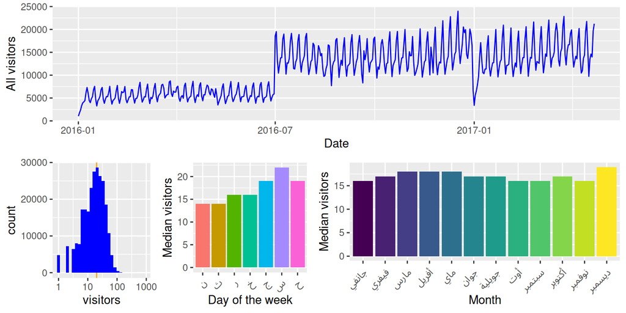

```r
Sys.setenv(LANG = "en_US.UTF-8")

p1 <- air_visits %>%
  group_by(visit_date) %>%
  summarise(all_visitors = sum(visitors)) %>%
  ggplot(aes(visit_date,all_visitors)) +
  geom_line(col = "blue") +
  labs(y = "All visitors", x = "Date")

p2 <- air_visits %>%
  ggplot(aes(visitors)) +
  geom_vline(xintercept = 20, color = "orange") +
  geom_histogram(fill = "blue", bins = 30) +
  scale_x_log10()

p3 <- air_visits %>%
  mutate(wday = wday(visit_date, label = TRUE, week_start = 1)) %>%
  group_by(wday) %>%
  summarise(visits = median(visitors)) %>%
  ggplot(aes(wday, visits, fill = wday)) +
  geom_col() +
  theme(legend.position = "none", axis.text.x  = element_text(angle=45, hjust=1, vjust=0.9)) +
  labs(x = "Day of the week", y = "Median visitors") +
  scale_fill_hue()

p4 <- air_visits %>%
  mutate(month = month(visit_date, label = TRUE)) %>%
  group_by(month) %>%
  summarise(visits = median(visitors)) %>%
  ggplot(aes(month, visits, fill = month)) +
  geom_col() +
  theme(legend.position = "none", axis.text.x  = element_text(angle=45, hjust=1, vjust=0.9)) +
  labs(x = "Month", y = "Median visitors")

layout <- matrix(c(1,1,1,1,2,3,4,4),2,4,byrow=TRUE)
multiplot(p1, p2, p3, p4, layout=layout)
```

We find: * There is an interesting long-term step structure in the overall time series. This might be related to new restaurants being added to the data base. In addition, we already see a periodic pattern that most likely corresponds to a weekly cycle.

- The number of guests per visit per restaurant per day peaks at around 20 (the orange line). The distribution extends up to 100 and, in rare cases, beyond.
- Friday and the weekend appear to be the most popular days; which is to be expected. `Monday` and `Tuesday` have the lowest numbers of average visitors.
- Also during the year there is a certain amount of variation. `Dec` appears to be the most popular month for restaurant visits. The period of `Mar - May` is consistently busy.

We will be forecasting for the last week of April plus May 2017, so let’s look at this time range in our 2016 training data:

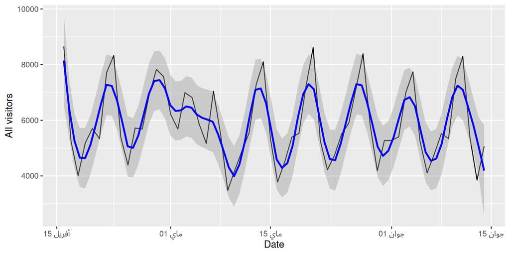

```r
air_visits %>%
  filter(visit_date > ymd("2016-04-15") & visit_date < ymd("2016-06-15")) %>%
  group_by(visit_date) %>%
  summarise(all_visitors = sum(visitors)) %>%
  ggplot(aes(visit_date,all_visitors)) +
  geom_line() +
  geom_smooth(method = "loess", color = "blue", span = 1/7) +
  labs(y = "All visitors", x = "Date")
```

Here, the black line is the date and the blue line corresponds to a smoothing fit with a corresponding grey confidence area. We see again the weekly period and also the impact of the aforementioned Golden Week, which in 2016 happened between Apr 29 and May 5.

`Seaborn` doesn’t have a direct equivalent to the `geom_smooth` function with the loess method. However, we can achieve a similar effect using the seaborn.lineplot function combined with a `lowess` smoother from the `statsmodels` library.

```python
locale.setlocale(locale.LC_ALL,'en_US.utf8')
```

```
## 'en_US.utf8'
```

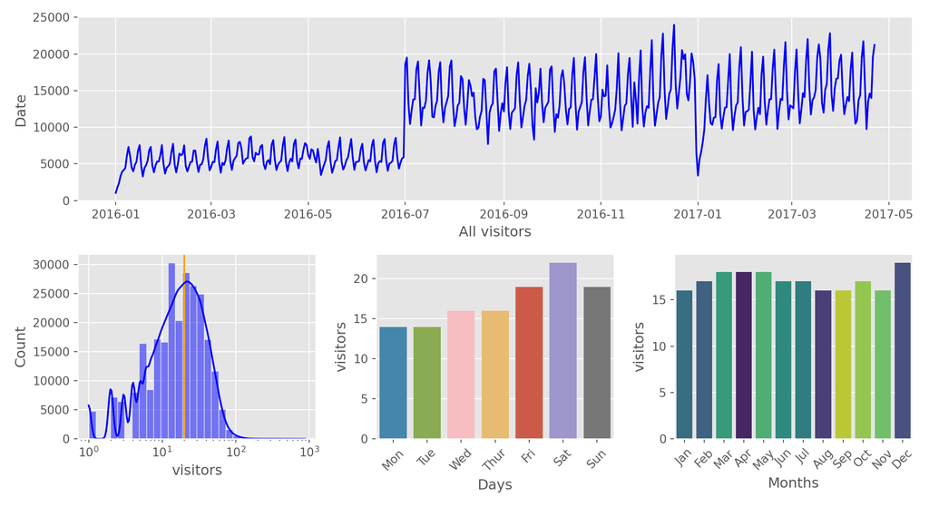

```python
# Set the language to English
#plt.rcParams['axes.formatter.use_locale'] = False
#plt.rcParams['pgf.rcfonts'] = False
#plt.rcParams['pdf.fonttype'] = 42

p1_data = air_visits.groupby('visit_date')['visitors'].sum().reset_index()

p3_data = air_visits.assign(wday=air_visits['visit_date'].dt.day_name()).groupby('wday')['visitors'].median().reset_index()

p4_data = air_visits.assign(month=air_visits['visit_date'].dt.strftime('%b')).groupby('month')['visitors'].median().reset_index()


plt.style.use('ggplot')
fig = plt.figure(figsize=(11, 6))
gs = fig.add_gridspec(2, 3)

# First row
ax1 = fig.add_subplot(gs[0, :])
sns.lineplot(data=p1_data, x='visit_date', y='visitors', color='blue', ax=ax1)
ax1.set_xlabel('All visitors')
ax1.set_ylabel('Date')

# Second row
ax2 = fig.add_subplot(gs[1, 0])
plt.axvline(x=20, color='orange')
plt.xscale('log')
sns.histplot(data=air_visits, x='visitors', bins=30, color='blue', kde=True, ax=ax2)

ax3 = fig.add_subplot(gs[1, 1])
order = [ "Monday", "Tuesday", "Wednesday", "Thursday", "Friday", "Saturday", "Sunday"]
ax3.set_xticklabels( ('Mon', 'Tue','Wed', 'Thur', 'Fri', 'Sat', 'Sun') )
p3 = sns.barplot(data=p3_data, x='wday', y='visitors', hue='wday',
                  legend=False, ax=ax3, order=order) #palette='viridis',
p3 = plt.xticks(rotation=45)
#ax3.set_xticklabels(ax3.get_xticklabels(), rotation=45)
ax3.set_xlabel('Days')

ax4 = fig.add_subplot(gs[1, 2])
order = [ "Jan", "Feb", "Mar", "Apr", "May", "Jun","Jul", "Aug", "Sep", "Oct", "Nov", "Dec"]
p4 = sns.barplot(data=p4_data, x='month', y='visitors', hue='month',
         legend=False, ax=ax4, order=order, palette='viridis')
p4 = plt.xticks(rotation=45)
#ax4.set_xticklabels(ax4.get_xticklabels(), rotation=45)
ax4.set_xlabel('Months')

plt.tight_layout()
plt.show()
```

- In this code, we use add_gridspec to create a 2x3 grid of subplots.
- Then, we manually add subplots to specific positions using add_subplot.
- This way, you have full control over the layout of the plots.

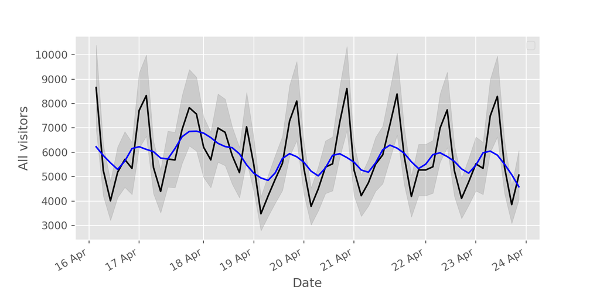

```python
from statsmodels.nonparametric.smoothers_lowess import lowess
import matplotlib.dates as mdates
#locale.setlocale(locale.LC_ALL,'en_US.utf8')

plt.style.use('ggplot')

# Assuming air_visits is your DataFrame
subset_data = air_visits[(air_visits['visit_date'] > '2016-04-15') &
                        (air_visits['visit_date'] < '2016-06-15')]
# Calculate the total visitors for each visit_date
agg_data = subset_data.groupby('visit_date')['visitors'].sum().reset_index()
#agg_data.visit_date = agg_data.visit_date.dt.strftime('%d %b')

# build the figure
fig, ax = plt.subplots()

# Scatter plot of the data
p = sns.lineplot(data = agg_data, x='visit_date', y='visitors',
                 color='black', label='Data')
#p= sns.regplot(data=agg_data, x='visit_date', y='visitors',
#                color='black', lowess=True, ax=plt.gca())

# set dates format
p = ax.set(xticklabels = agg_data['visit_date'].dt.strftime('%d %b'))
p = plt.fill_between(agg_data.visit_date, agg_data.visitors*0.8,
                        agg_data.visitors*1.2,
                        alpha=0.25, label='LOWESS uncertainty',
                        color = "grey")


# put the labels at 45deg since they tend to be too long
#p = plt.xticks(rotation=45)
fig.autofmt_xdate()

# # Ensure that the x.axis text is spacieux
p = ax.xaxis.set_major_locator(mdates.AutoDateLocator())

## Calculate the lowess smoothed line
smoothed = lowess(agg_data['visitors'],
           agg_data['visit_date'].astype('datetime64[s]'),  frac=1/7)
## Plot the smoothed line
p = plt.plot(agg_data['visit_date'], smoothed[:, 1],
    color='blue', label='Lowess Smoother')

# Set labels and legend
p = plt.xlabel('Date')
p = plt.ylabel('All visitors')
plt.legend("")

# Show the plot
plt.show(p)
```

## 4.2 Air Reservations

Let’s see how our reservations data compares to the actual visitor numbers. We start with the air restaurants and visualise their visitor volume through reservations for each day, alongside the hours of these visits and the time between making a reservation and visiting the restaurant:

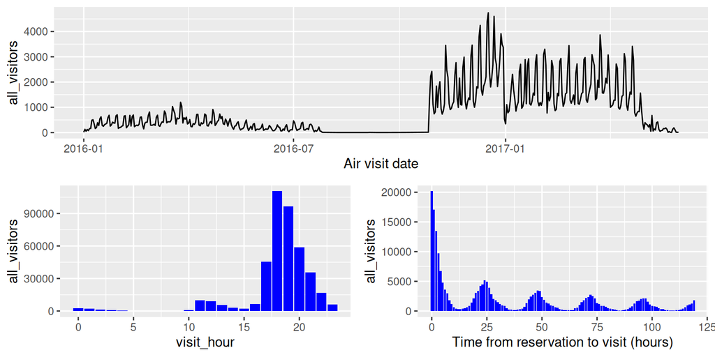

```r
foo <- air_reserve %>%
  mutate(reserve_date = date(reserve_datetime),
         reserve_hour = hour(reserve_datetime),
         reserve_wday = wday(reserve_datetime, label = TRUE, week_start = 1),
         visit_date = date(visit_datetime),
         visit_hour = hour(visit_datetime),
         visit_wday = wday(visit_datetime, label = TRUE, week_start = 1),
         diff_hour = time_length(visit_datetime - reserve_datetime, unit = "hour"),
         diff_day = time_length(visit_datetime - reserve_datetime, unit = "day")
         )

p1 <- foo %>%
  group_by(visit_date) %>%
  summarise(all_visitors = sum(reserve_visitors)) %>%
  ggplot(aes(visit_date, all_visitors)) +
  geom_line() +
  labs(x = "Air visit date")

p2 <- foo %>%
  group_by(visit_hour) %>%
  summarise(all_visitors = sum(reserve_visitors)) %>%
  ggplot(aes(visit_hour, all_visitors)) +
  geom_col(fill = "blue")

p3 <- foo %>%
  filter(diff_hour < 24*5) %>%
  group_by(diff_hour) %>%
  summarise(all_visitors = sum(reserve_visitors)) %>%
  ggplot(aes(diff_hour, all_visitors)) +
  geom_col(fill = "blue") +
  labs(x = "Time from reservation to visit (hours)")

layout <- matrix(c(1,1,2,3),2,2, byrow=TRUE)
multiplot(p1, p2, p3, layout=layout)
```

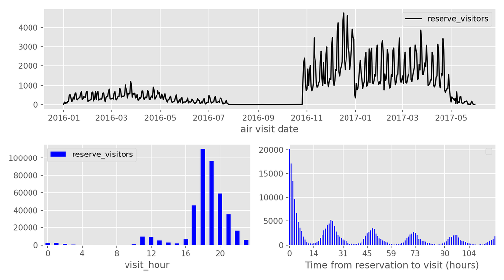

```python
# Assuming 'air_reserve' is your DataFrame
foo = air_reserve.copy()
foo['reserve_date'] = foo['reserve_datetime'].dt.date
foo['reserve_hour'] = foo['reserve_datetime'].dt.hour
foo['reserve_wday'] = foo['reserve_datetime'].dt.day_name()
foo['visit_date'] = foo['visit_datetime'].dt.date
foo['visit_hour'] = foo['visit_datetime'].dt.hour
foo['visit_wday'] = foo['visit_datetime'].dt.day_name()
foo['diff_hour'] = (foo['visit_datetime'] - foo['reserve_datetime']).dt.total_seconds() / 3600
foo['diff_day'] = (foo['visit_datetime'] - foo['reserve_datetime']).dt.days

p1 = foo.groupby('visit_date')['reserve_visitors'].sum().reset_index()
p2 = foo.groupby('visit_hour')['reserve_visitors'].sum().reset_index()
p3 = foo[foo['diff_hour'] < 24*5].groupby('diff_hour')['reserve_visitors'].sum().reset_index()

# Multiplot layout
fig = plt.figure(figsize=(9, 5))
gs = GridSpec(2, 2, figure=fig)
plt.style.use('ggplot')

ax1 = fig.add_subplot(gs[0, :])
ax2 = fig.add_subplot(gs[1, 0])
ax3 = fig.add_subplot(gs[1, 1])

p1.plot(x='visit_date', y='reserve_visitors', kind='line', ax=ax1, color = 'black')
p1= ax1.set_xlabel('air visit date')
p1= plt.legend("")

p2.plot(x='visit_hour', y='reserve_visitors', kind='bar', color='blue', ax=ax2)
p2= ax2.set_xticklabels(ax2.get_xticklabels(), rotation=0)
p2= ax2.xaxis.set_major_locator(mdates.AutoDateLocator())
p2= plt.legend("")

p3.plot(x='diff_hour', y='reserve_visitors', kind='bar', color='blue', ax=ax3)
p3= ax3.set_xlabel('Time from reservation to visit (hours)')
p3= ax3.set_xticklabels(ax3.get_xticklabels(), rotation=0)
p3= ax3.xaxis.set_major_locator(mdates.AutoDateLocator())
p3= ax3.xaxis.set_major_formatter(FormatStrFormatter('%.0f'))
p3= plt.legend("")

plt.tight_layout()
plt.show()
```

## 4.3 HPG Reservations

In the same style as above, here are the hpg reservations:

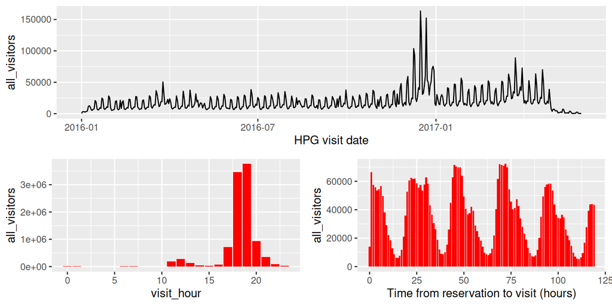

```r
foo <- hpg_reserve %>%
  mutate(reserve_date = date(reserve_datetime),
         reserve_hour = hour(reserve_datetime),
         visit_date = date(visit_datetime),
         visit_hour = hour(visit_datetime),
         diff_hour = time_length(visit_datetime - reserve_datetime, unit = "hour"),
         diff_day = time_length(visit_datetime - reserve_datetime, unit = "day")
         )

p1 <- foo %>%
  group_by(visit_date) %>%
  summarise(all_visitors = sum(reserve_visitors)) %>%
  ggplot(aes(visit_date, all_visitors)) +
  geom_line() +
  labs(x = "HPG visit date")

p2 <- foo %>%
  group_by(visit_hour) %>%
  summarise(all_visitors = sum(reserve_visitors)) %>%
  ggplot(aes(visit_hour, all_visitors)) +
  geom_col(fill = "red")

p3 <- foo %>%
  filter(diff_hour < 24*5) %>%
  group_by(diff_hour) %>%
  summarise(all_visitors = sum(reserve_visitors)) %>%
  ggplot(aes(diff_hour, all_visitors)) +
  geom_col(fill = "red") +
  labs(x = "Time from reservation to visit (hours)")

layout <- matrix(c(1,1,2,3),2,2,byrow=TRUE)
multiplot(p1, p2, p3, layout=layout)
```

We find:

- Here the visits after reservation follow a more orderly pattern, with a clear spike in Dec 2016. As above for the air data, we also see reservation visits dropping off as we get closer to the end of the time frame.
- Again, most reservations are for dinner, and we see another nice 24-hour pattern for making these reservations. It’s worth noting that here the last few hours before the visit don’t see more volume than the 24 or 48 hours before. This is in stark constrast to the air data.

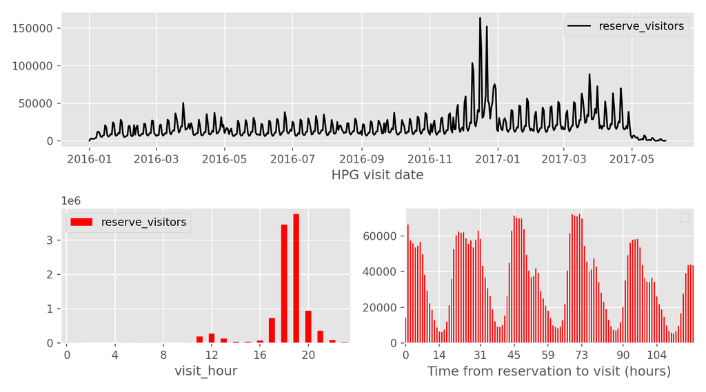

```python
foo = hpg_reserve.copy()
foo['reserve_date'] = foo['reserve_datetime'].dt.date
foo['reserve_hour'] = foo['reserve_datetime'].dt.hour
foo['visit_date'] = foo['visit_datetime'].dt.date
foo['visit_hour'] = foo['visit_datetime'].dt.hour
foo['diff_hour'] = (foo['visit_datetime'] - foo['reserve_datetime']).dt.total_seconds() / 3600
foo['diff_day'] = (foo['visit_datetime'] - foo['reserve_datetime']).dt.days

p1 = foo.groupby('visit_date')['reserve_visitors'].sum().reset_index()
p2 = foo.groupby('visit_hour')['reserve_visitors'].sum().reset_index()
p3 = foo[foo['diff_hour'] < 24*5].groupby('diff_hour')['reserve_visitors'].sum().reset_index()

# Multiplot layout
fig = plt.figure(figsize=(9, 5))
gs = GridSpec(2, 2, figure=fig)
plt.style.use('ggplot')

ax1 = fig.add_subplot(gs[0, :])
ax2 = fig.add_subplot(gs[1, 0])
ax3 = fig.add_subplot(gs[1, 1])

p1.plot(x='visit_date', y='reserve_visitors', kind='line', color='black', ax=ax1)
p1= ax1.set_xlabel('HPG visit date')
#p1= ax1.set_xticklabels(ax1.get_xticklabels(), rotation=45)
p1= ax1.xaxis.set_major_locator(mdates.AutoDateLocator())
p1= plt.legend("")

p2.plot(x='visit_hour', y='reserve_visitors', kind='bar', color='red', ax=ax2)
p2= ax2.set_xticklabels(ax2.get_xticklabels(), rotation=0)
p2= ax2.xaxis.set_major_locator(mdates.AutoDateLocator())
p2= plt.legend("")

p3.plot(x='diff_hour', y='reserve_visitors', kind='bar', color='red', ax=ax3)
p3= ax3.set_xlabel('Time from reservation to visit (hours)')
p3= ax3.set_xticklabels(ax3.get_xticklabels(), rotation=0)
p3= ax3.xaxis.set_major_locator(mdates.AutoDateLocator())
p3= ax3.xaxis.set_major_formatter(FormatStrFormatter('%.0f'))
p3= plt.legend("")


plt.tight_layout()
plt.show()
```

## 4.4 Air Store

After visualising the temporal aspects, let’s now look at the spatial information. Note, that according to the [data description](https://www.kaggle.com/c/recruit-restaurant-visitor-forecasting/data) the “latitude and longitude are the latitude and longitude of the area to which the store belongs”. This is meant to discourage us from identifying specific restaurants. I would be surprised if nobody tried anyway, though.

This is a fully interactive and zoomable map of all the air restaurants. Click on the clusters to break them up into smaller clusters and ultimately into the individual restaurants, which are labelled by their genre. The map nicely visualises the fact that many restaurants share common coordinates, since those coordinates refer to the area of the restaurant. Click on the single markers to see their air_store_id. The map is powered by the [leaflet](https://rstudio.github.io/leaflet/) package, which includes a variety of cool tools for interactive maps. Have fun exploring!

```r
leaflet(air_store) %>%
  addTiles() %>%
  addProviderTiles("CartoDB.Positron") %>%
  addMarkers(~longitude, ~latitude,
             popup = ~air_store_id, label = ~air_genre_name,
             clusterOptions = markerClusterOptions())
```

[interactive chart not shown]

In Python, you can achieve a similar map using the [folium](https://pypi.org/project/folium/) library.

```python
import warnings
warnings.filterwarnings('ignore')

# Create a map centered at a specific location
m = folium.Map(location=[35.6528, 139.8395], zoom_start=6)

# Add tiles (you can choose different providers)
folium.TileLayer(tiles='CartoDB positron').add_to(m)
```

```
## <folium.raster_layers.TileLayer object at 0x7fd7f8d1c7f0>
```

```python
# Create a MarkerCluster object
marker_cluster = MarkerCluster().add_to(m)

## Add markers from the air_store dataset
# for index, row in air_store.iterrows():
#     folium.Marker(location=[row['latitude'], row['longitude']],
#                   popup=row['air_store_id'],
#                   icon=None,
#                   tooltip=row['air_genre_name']).add_to(marker_cluster)


# Define a function to add markers
def add_marker(row):
    folium.Marker(location=[row['latitude'], row['longitude']],
                  popup=row['air_store_id'],
                  icon=None,
                  tooltip=row['air_genre_name']).add_to(marker_cluster)

# Apply the function to each row of the DataFrame
air_store.apply(add_marker, axis=1)
```

```
## 0      None
## 1      None
## 2      None
## 3      None
## 4      None
##        ...
## 824    None
## 825    None
## 826    None
## 827    None
## 828    None
## Length: 829, dtype: object
```

```python
# Display the map
m
```

Make this Notebook Trusted to load map: File -> Trust Notebook

[interactive chart not shown]